# Early Detection of Alzheimer's using MRI data and Machine Learning

### 1. Alzheimer's Disease

- Alzheimer's disease (AD) is a neurodegenerative disorder of uncertain cause and pathogenesis that primarily affects older adults and is the most common cause of dementia.
- The earliest clinical manifestation of AD is selective memory impairment and while treatments are available to ameliorate some symptoms, there is no cure currently available.
- Brain Imaging via magnetic resonance imaging (MRI), is used for evaluation of patients with suspected AD.
- MRI findings include both, local and generalized shrinkage of brain tissue.
- Some studies have suggested that MRI features may predict rate of decline of AD and may guide therapy in the future.
- In order to reach that stage clinicians and researchers will have to make use of machine learning techniques that can accurately predict progress of a patient from mild cognitive impairment to dementia.
- We propose to develop a sound model that can help clinicians do that and predict early alzheimer's.

### 2. Dataset Description

#### Columns Description

| Column | Description |
| --- | --- |
| EDUC | Years of education |
| SES | Socioeconomic Status |
| MMSE | Mini Mental State Examination |
| CDR | Clinical Dementia Rating |
| eTIV | Estimated Total Intracranial Volume |
| nWBV | Normalize Whole Brain Volume |
| ASF | Atlas Scaling Factor |

### 3. Exploratory Data Analysis (EDA)

Exploring the relationship between each feature of MRI tests and dementia of the patient.

```python
# Importing packages
import pandas as pd
import numpy as np
import seaborn as sns
import matplotlib.pyplot as plt

# Suppress warnings
import warnings
warnings.filterwarnings('ignore')
```

```python
df = pd.read_csv("https://raw.githubusercontent.com/adityagurbaxani/dmpa-alzheimers/77e9fa74aa629f1122229e173ff6b262388740dc/datasets/oasis_longitudinal.csv")
df.head()
```

|  | Subject ID | MRI ID | Group | Visit | MR Delay | M/F | Hand | Age | EDUC | SES | MMSE | CDR | eTIV | nWBV | ASF |
| --- | --- | --- | --- | --- | --- | --- | --- | --- | --- | --- | --- | --- | --- | --- | --- |
| 0 | OAS2_0001 | OAS2_0001_MR1 | Nondemented | 1 | 0 | M | R | 87 | 14 | 2.0 | 27.0 | 0.0 | 1987 | 0.696 | 0.883 |
| 1 | OAS2_0001 | OAS2_0001_MR2 | Nondemented | 2 | 457 | M | R | 88 | 14 | 2.0 | 30.0 | 0.0 | 2004 | 0.681 | 0.876 |
| 2 | OAS2_0002 | OAS2_0002_MR1 | Demented | 1 | 0 | M | R | 75 | 12 | NaN | 23.0 | 0.5 | 1678 | 0.736 | 1.046 |
| 3 | OAS2_0002 | OAS2_0002_MR2 | Demented | 2 | 560 | M | R | 76 | 12 | NaN | 28.0 | 0.5 | 1738 | 0.713 | 1.010 |
| 4 | OAS2_0002 | OAS2_0002_MR3 | Demented | 3 | 1895 | M | R | 80 | 12 | NaN | 22.0 | 0.5 | 1698 | 0.701 | 1.034 |

- Target variable is the 'Group': Demented or Nondemented
- We will only consider patient data of the 1st visit in our analysis and modeling

```python
# Describing the dataset
df.describe()
#df.describe().transpose()[['mean','std','min','max']]
```

|  | Visit | MR Delay | Age | EDUC | SES | MMSE | CDR | eTIV | nWBV | ASF |
| --- | --- | --- | --- | --- | --- | --- | --- | --- | --- | --- |
| count | 373.000000 | 373.000000 | 373.000000 | 373.000000 | 354.000000 | 371.000000 | 373.000000 | 373.000000 | 373.000000 | 373.000000 |
| mean | 1.882038 | 595.104558 | 77.013405 | 14.597855 | 2.460452 | 27.342318 | 0.290885 | 1488.128686 | 0.729568 | 1.195461 |
| std | 0.922843 | 635.485118 | 7.640957 | 2.876339 | 1.134005 | 3.683244 | 0.374557 | 176.139286 | 0.037135 | 0.138092 |
| min | 1.000000 | 0.000000 | 60.000000 | 6.000000 | 1.000000 | 4.000000 | 0.000000 | 1106.000000 | 0.644000 | 0.876000 |
| 25% | 1.000000 | 0.000000 | 71.000000 | 12.000000 | 2.000000 | 27.000000 | 0.000000 | 1357.000000 | 0.700000 | 1.099000 |
| 50% | 2.000000 | 552.000000 | 77.000000 | 15.000000 | 2.000000 | 29.000000 | 0.000000 | 1470.000000 | 0.729000 | 1.194000 |
| 75% | 2.000000 | 873.000000 | 82.000000 | 16.000000 | 3.000000 | 30.000000 | 0.500000 | 1597.000000 | 0.756000 | 1.293000 |
| max | 5.000000 | 2639.000000 | 98.000000 | 23.000000 | 5.000000 | 30.000000 | 2.000000 | 2004.000000 | 0.837000 | 1.587000 |

```python
df = df[df['Visit'] == 1] #using only 1st visit data
df.reset_index(drop=True, inplace=True) #Reset dataframe index
df.head()
```

|  | Subject ID | MRI ID | Group | Visit | MR Delay | M/F | Hand | Age | EDUC | SES | MMSE | CDR | eTIV | nWBV | ASF |
| --- | --- | --- | --- | --- | --- | --- | --- | --- | --- | --- | --- | --- | --- | --- | --- |
| 0 | OAS2_0001 | OAS2_0001_MR1 | Nondemented | 1 | 0 | M | R | 87 | 14 | 2.0 | 27.0 | 0.0 | 1987 | 0.696 | 0.883 |
| 1 | OAS2_0002 | OAS2_0002_MR1 | Demented | 1 | 0 | M | R | 75 | 12 | NaN | 23.0 | 0.5 | 1678 | 0.736 | 1.046 |
| 2 | OAS2_0004 | OAS2_0004_MR1 | Nondemented | 1 | 0 | F | R | 88 | 18 | 3.0 | 28.0 | 0.0 | 1215 | 0.710 | 1.444 |
| 3 | OAS2_0005 | OAS2_0005_MR1 | Nondemented | 1 | 0 | M | R | 80 | 12 | 4.0 | 28.0 | 0.0 | 1689 | 0.712 | 1.039 |
| 4 | OAS2_0007 | OAS2_0007_MR1 | Demented | 1 | 0 | M | R | 71 | 16 | NaN | 28.0 | 0.5 | 1357 | 0.748 | 1.293 |

```python
# Making the Categorical variables uniform
print('Group:', df['Group'].unique())
print('M/F:', df['M/F'].unique())
print('Hand:', df['Hand'].unique())
```

```
Group: ['Nondemented' 'Demented' 'Converted']
M/F: ['M' 'F']
Hand: ['R']
```

```python
# Encoding the Categorical Variables
df['M/F'] = df['M/F'].replace(['M','F'],[1,0]) # Male:1, Female:0
df['Group'] = df['Group'].replace(['Converted'],['Demented']) # Chaning 'Converted' to 'Demented'
df['Group'] = df['Group'].replace(['Demented','Nondemented'],[1,0]) # Demented:1, Nondemented:0
df.head()
```

|  | Subject ID | MRI ID | Group | Visit | MR Delay | M/F | Hand | Age | EDUC | SES | MMSE | CDR | eTIV | nWBV | ASF |
| --- | --- | --- | --- | --- | --- | --- | --- | --- | --- | --- | --- | --- | --- | --- | --- |
| 0 | OAS2_0001 | OAS2_0001_MR1 | 0 | 1 | 0 | 1 | R | 87 | 14 | 2.0 | 27.0 | 0.0 | 1987 | 0.696 | 0.883 |
| 1 | OAS2_0002 | OAS2_0002_MR1 | 1 | 1 | 0 | 1 | R | 75 | 12 | NaN | 23.0 | 0.5 | 1678 | 0.736 | 1.046 |
| 2 | OAS2_0004 | OAS2_0004_MR1 | 0 | 1 | 0 | 0 | R | 88 | 18 | 3.0 | 28.0 | 0.0 | 1215 | 0.710 | 1.444 |
| 3 | OAS2_0005 | OAS2_0005_MR1 | 0 | 1 | 0 | 1 | R | 80 | 12 | 4.0 | 28.0 | 0.0 | 1689 | 0.712 | 1.039 |
| 4 | OAS2_0007 | OAS2_0007_MR1 | 1 | 1 | 0 | 1 | R | 71 | 16 | NaN | 28.0 | 0.5 | 1357 | 0.748 | 1.293 |

```python
# Drop unnecessary columns
df.drop(['MRI ID', 'Visit', 'Hand','MR Delay'], axis=1, inplace=True)
df.head()
```

|  | Subject ID | Group | M/F | Age | EDUC | SES | MMSE | CDR | eTIV | nWBV | ASF |
| --- | --- | --- | --- | --- | --- | --- | --- | --- | --- | --- | --- |
| 0 | OAS2_0001 | 0 | 1 | 87 | 14 | 2.0 | 27.0 | 0.0 | 1987 | 0.696 | 0.883 |
| 1 | OAS2_0002 | 1 | 1 | 75 | 12 | NaN | 23.0 | 0.5 | 1678 | 0.736 | 1.046 |
| 2 | OAS2_0004 | 0 | 0 | 88 | 18 | 3.0 | 28.0 | 0.0 | 1215 | 0.710 | 1.444 |
| 3 | OAS2_0005 | 0 | 1 | 80 | 12 | 4.0 | 28.0 | 0.0 | 1689 | 0.712 | 1.039 |
| 4 | OAS2_0007 | 1 | 1 | 71 | 16 | NaN | 28.0 | 0.5 | 1357 | 0.748 | 1.293 |

```python
# Create copy of DataFrame
df1 = df
df.isnull().sum()
```

```
Subject ID    0
Group         0
M/F           0
Age           0
EDUC          0
SES           8
MMSE          0
CDR           0
eTIV          0
nWBV          0
ASF           0
dtype: int64
```

```python
#Using median value to replace the NULL values
SES = df['SES'].median()
df['SES'] = df['SES'].fillna(SES)
df.isnull().sum()
```

```
Subject ID    0
Group         0
M/F           0
Age           0
EDUC          0
SES           0
MMSE          0
CDR           0
eTIV          0
nWBV          0
ASF           0
dtype: int64
```

```python
# bar drawing function
def bar_chart(feature):
    Demented = df[df['Group']==1][feature].value_counts()
    Nondemented = df[df['Group']==0][feature].value_counts()
    df_bar = pd.DataFrame([Demented,Nondemented])
    df_bar.index = ['Demented','Nondemented']
    df_bar.plot(kind='bar',stacked=True, figsize=(8,5))
```

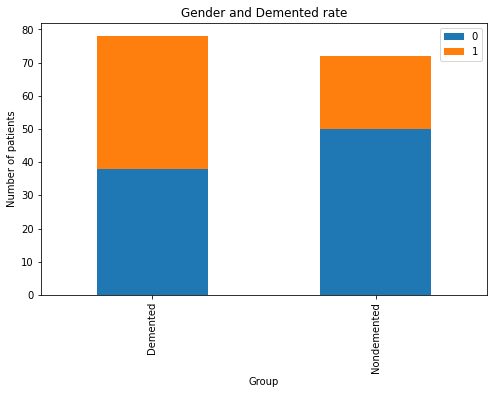

```python
# Gender  and  Group ( Female=0, Male=1)
bar_chart('M/F')
plt.xlabel('Group')
plt.ylabel('Number of patients')
plt.legend()
plt.title('Gender and Demented rate')
```

The above graph indicates that men are more likely with dementia than women.

```
(15.3, 30.0)
```

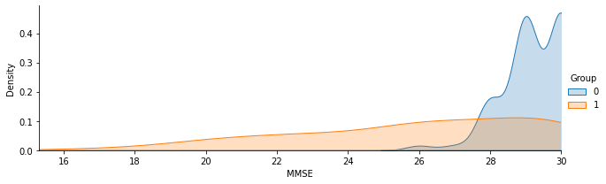

```python
#MMSE : Mini Mental State Examination
# Nondemented = 0, Demented =1
# Nondemented has higher test result ranging from 25 to 30.
#Min 17 ,MAX 30
facet= sns.FacetGrid(df,hue="Group", aspect=3)
facet.map(sns.kdeplot,'MMSE',shade= True)
facet.set(xlim=(0, df['MMSE'].max()))
facet.add_legend()
plt.xlim(15.30)
```

The chart shows Nondemented group got much more higher MMSE scores than Demented group.

```
(0.6, 0.9)
```

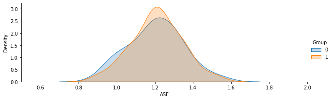

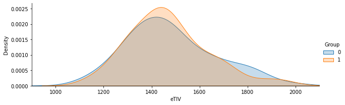

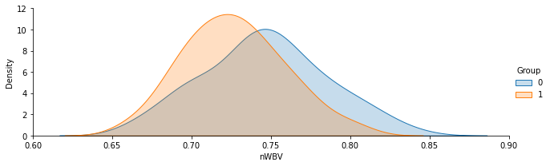

```python
#bar_chart('ASF') = Atlas Scaling Factor
facet= sns.FacetGrid(df,hue="Group", aspect=3)
facet.map(sns.kdeplot,'ASF',shade= True)
facet.set(xlim=(0, df['ASF'].max()))
facet.add_legend()
plt.xlim(0.5, 2)

#eTIV = Estimated Total Intracranial Volume
facet= sns.FacetGrid(df,hue="Group", aspect=3)
facet.map(sns.kdeplot,'eTIV',shade= True)
facet.set(xlim=(0, df['eTIV'].max()))
facet.add_legend()
plt.xlim(900, 2100)

#'nWBV' = Normalized Whole Brain Volume
# Nondemented = 0, Demented =1
facet= sns.FacetGrid(df,hue="Group", aspect=3)
facet.map(sns.kdeplot,'nWBV',shade= True)
facet.set(xlim=(0, df['nWBV'].max()))
facet.add_legend()
plt.xlim(0.6,0.9)
```

The chart indicates that Nondemented group has higher brain volume ratio than Demented group. This is assumed since the diseases cause shrinking of the brain tissue.

```
(50.0, 100.0)
```

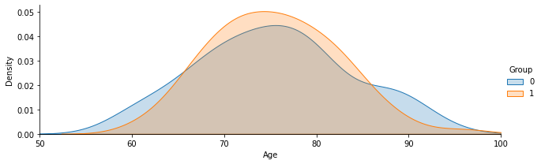

```python
#AGE. Nondemented =0, Demented =0
facet= sns.FacetGrid(df,hue="Group", aspect=3)
facet.map(sns.kdeplot,'Age',shade= True)
facet.set(xlim=(0, df['Age'].max()))
facet.add_legend()
plt.xlim(50,100)
```

There is a higher concentration of 70-80 years old in the Demented patient group than those in the nondemented patients. We guess patients who suffered from that kind of disease has lower survival rate so that there are a few of 90 years old.

```
(0.0, 0.16)
```

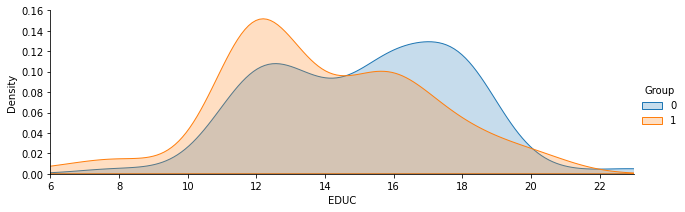

```python
#'EDUC' = Years of Education
# Nondemented = 0, Demented =1
facet= sns.FacetGrid(df,hue="Group", aspect=3)
facet.map(sns.kdeplot,'EDUC',shade= True)
facet.set(xlim=(df['EDUC'].min(), df['EDUC'].max()))
facet.add_legend()
plt.ylim(0, 0.16)
```

#### EDA Summary

1. Men are more likely with demented, an Alzheimer's Disease, than Women.
2. Demented patients were less educated in terms of years of education.
3. Nondemented group has higher brain volume than Demented group.
4. Higher concentration of 70-80 years old in Demented group than those in the nondemented patients.

### 4. Data Pre-processing

```python
#Switch back to origional DataFrame
df = df1
```

```python
df.groupby(['EDUC'])['SES'].median()
```

```
EDUC
6     4.0
8     5.0
11    4.0
12    3.0
13    2.0
14    3.0
15    2.0
16    2.0
17    1.0
18    2.0
20    1.0
23    1.0
Name: SES, dtype: float64
```

```python
# Using median for imputation
df["SES"].fillna(df.groupby("EDUC")["SES"].transform("median"), inplace=True)
```

```python
# Confirm that all missing values have been filled
df['SES'].isnull().value_counts()
```

```
False    150
Name: SES, dtype: int64
```

#### Splitting the Dataset

```python
from sklearn.model_selection import train_test_split
from sklearn import preprocessing
from sklearn.preprocessing import MinMaxScaler
from sklearn.model_selection import cross_val_score
```

```python
# Dataset with imputation
Y = df['Group'].values # Target for the model
X = df[['M/F', 'Age', 'EDUC', 'SES', 'MMSE', 'eTIV', 'nWBV', 'ASF']] # Features we use

# Feature scaling
X_scaled = (X - X.min())/(X.max() - X.min())

# splitting into three sets
X_train, X_test, y_train, y_test = train_test_split(X_scaled, Y, random_state=0)
```

### 5. Building the Models

We use area under the receiver operating characteristic curve (AUC) as our main performance measure. We believe that in case of medical diagnostics for non-life threatening terminal diseases like most neurodegenerative diseases it is important to have a high true positive rate so that all patients with alzheimer's are identified as early as possible. But we also want to make sure that the false positive rate is as low as possible since we do not want to misdiagnose a healthy adult as demented and begin medical therapy. Hence AUC seemed like a ideal choice for a performance measure.

We will also be looking at accuracy and recall for each model.

```python
from sklearn.linear_model import LogisticRegression
from sklearn.svm import SVC
from sklearn.tree import DecisionTreeClassifier
from sklearn.ensemble import RandomForestClassifier
from sklearn.ensemble import AdaBoostClassifier
from sklearn.metrics import confusion_matrix, accuracy_score, recall_score, roc_curve, auc
from sklearn.metrics import classification_report
from sklearn.metrics import confusion_matrix
from sklearn.metrics import ConfusionMatrixDisplay
from sklearn.metrics import roc_auc_score
from sklearn.metrics import precision_recall_fscore_support as score
import matplotlib.pyplot as plt
from sklearn import metrics
```

```python
# DataFrame to store all performance metric for each Model
acc = pd.DataFrame(columns = ['Model', 'Precision', 'Recall', 'F-Score', 'roc_auc'])
```

#### 5A. Logistic Regression

```
              precision    recall  f1-score   support

           0       0.71      0.83      0.77        18
           1       0.82      0.70      0.76        20

    accuracy                           0.76        38
   macro avg       0.77      0.77      0.76        38
weighted avg       0.77      0.76      0.76        38
```

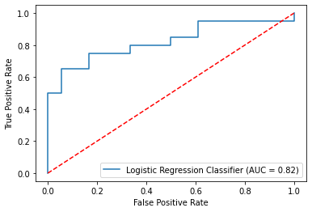

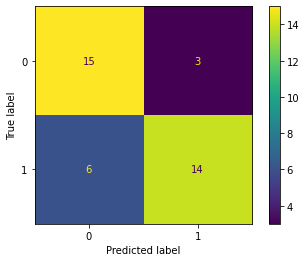

```python
lgclf = LogisticRegression(random_state = 97)
lgcclf = lgclf.fit(X_train,y_train)
y_pred_proba = lgclf.predict_proba(X_test)
y_pred = lgclf.predict(X_test)
print(classification_report(y_test, y_pred))
fpr, tpr, thresholds = metrics.roc_curve(y_test,y_pred_proba[:,1],drop_intermediate=True)
roc_auc = metrics.auc(fpr, tpr)
display = metrics.RocCurveDisplay(fpr=fpr, tpr=tpr, roc_auc=roc_auc, estimator_name='Logistic Regression Classifier')
display.plot()  # doctest: +SKIP
plt.plot([0, 1], [0, 1],'r--')
plt.show()
cm = confusion_matrix(y_test, y_pred)
cm_display = ConfusionMatrixDisplay(cm,display_labels=[0,1]).plot()
```

```python
precision,recall,fscore,support=score(y_test,y_pred,average='macro')
print('Precision : {}'.format(precision))
print('Recall    : {}'.format(recall))
print('F-score   : {}'.format(fscore))
#print('Support   : {}'.format(support))

acc.loc[len(acc)] = ['LogisticRegression',precision,recall,fscore,roc_auc]
```

```
Precision : 0.76890756302521
Recall    : 0.7666666666666666
F-score   : 0.7629937629937629
```

#### 5B. SVM Classifier

```python
from sklearn.svm import LinearSVC
```

```
              precision    recall  f1-score   support

           0       0.71      0.83      0.77        18
           1       0.82      0.70      0.76        20

    accuracy                           0.76        38
   macro avg       0.77      0.77      0.76        38
weighted avg       0.77      0.76      0.76        38
```

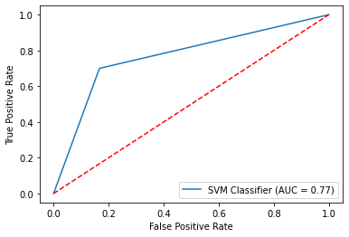

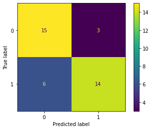

```python
svcclf = LinearSVC(random_state = 97)
svcclf = svcclf.fit(X_train,y_train)
y_pred = svcclf.predict(X_test)
print(classification_report(y_test, y_pred))
fpr, tpr, thresholds = metrics.roc_curve(y_test,y_pred,drop_intermediate=False)
roc_auc = metrics.auc(fpr, tpr)
display = metrics.RocCurveDisplay(fpr=fpr, tpr=tpr, roc_auc=roc_auc, estimator_name='SVM Classifier')
display.plot()
plt.plot([0, 1], [0, 1],'r--')# doctest: +SKIP
plt.show()
cm = confusion_matrix(y_test, y_pred)
cm_display = ConfusionMatrixDisplay(cm,display_labels=[0,1]).plot()
```

```python
precision,recall,fscore,support=score(y_test,y_pred,average='macro')
print('Precision : {}'.format(precision))
print('Recall    : {}'.format(recall))
print('F-score   : {}'.format(fscore))
#print('Support   : {}'.format(support))

acc.loc[len(acc)] = ['LinearSVC',precision,recall,fscore,roc_auc]
```

```
Precision : 0.76890756302521
Recall    : 0.7666666666666666
F-score   : 0.7629937629937629
```

#### 5C. Decision Tree Classifier

```python
from sklearn.tree import DecisionTreeClassifier
from sklearn import tree
```

```
              precision    recall  f1-score   support

           0       0.70      0.89      0.78        18
           1       0.87      0.65      0.74        20

    accuracy                           0.76        38
   macro avg       0.78      0.77      0.76        38
weighted avg       0.79      0.76      0.76        38
```

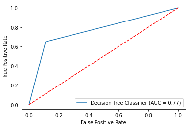

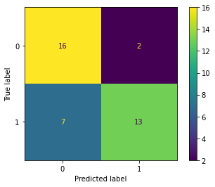

```python
dtclf = DecisionTreeClassifier(max_depth=4,random_state = 12)
dtclf = dtclf.fit(X_train,y_train)
y_pred = dtclf.predict(X_test)
print(classification_report(y_test, y_pred))
fpr, tpr, thresholds = metrics.roc_curve(y_test,y_pred,drop_intermediate=False)
roc_auc = metrics.auc(fpr, tpr)
display = metrics.RocCurveDisplay(fpr=fpr, tpr=tpr, roc_auc=roc_auc, estimator_name='Decision Tree Classifier')
display.plot()  # doctest: +SKIP
plt.plot([0, 1], [0, 1],'r--')
plt.show()
cm = confusion_matrix(y_test, y_pred)
cm_display = ConfusionMatrixDisplay(cm,display_labels=[0,1]).plot()
```

```python
precision,recall,fscore,support=score(y_test,y_pred,average='macro')
print('Precision : {}'.format(precision))
print('Recall    : {}'.format(recall))
print('F-score   : {}'.format(fscore))
#print('Support   : {}'.format(support))

acc.loc[len(acc)] = ['DecisionTreeClassifier',precision,recall,fscore,roc_auc]
```

```
Precision : 0.7811594202898551
Recall    : 0.7694444444444444
F-score   : 0.7616724738675958
```

```python
print("Feature importance: ")
np.array([X.columns.values.tolist(), list(dtclf.feature_importances_)]).T
```

```
Feature importance:
```

```
array([['M/F', '0.039066569579769256'],
       ['Age', '0.038936540317114764'],
       ['EDUC', '0.015892465435557064'],
       ['SES', '0.0'],
       ['MMSE', '0.579321967796191'],
       ['eTIV', '0.13401492245255286'],
       ['nWBV', '0.017481711979112777'],
       ['ASF', '0.1752858224397022']], dtype='<U32')
```

```python
from sklearn.tree import export_graphviz
import graphviz
dot_data=export_graphviz(dtclf, feature_names=X_train.columns.values.tolist(),out_file=None)
graph = graphviz.Source(dot_data)
graph
```

[figure not shown]

#### 5D. Random Forest Classifier

```python
from sklearn.ensemble import RandomForestClassifier
```

```
              precision    recall  f1-score   support

           0       0.76      0.89      0.82        18
           1       0.88      0.75      0.81        20

    accuracy                           0.82        38
   macro avg       0.82      0.82      0.82        38
weighted avg       0.83      0.82      0.82        38
```

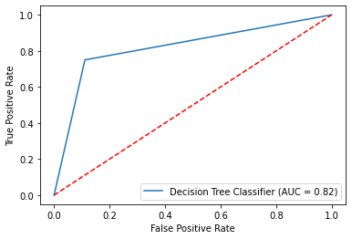

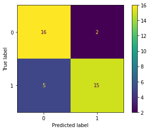

```python
rfclf = RandomForestClassifier(n_estimators=100, random_state=12)
rfclf = rfclf.fit(X_train,y_train)
y_pred = rfclf.predict(X_test)
print(classification_report(y_test, y_pred))
fpr, tpr, thresholds = metrics.roc_curve(y_test,y_pred,drop_intermediate=False)
roc_auc = metrics.auc(fpr, tpr)
display = metrics.RocCurveDisplay(fpr=fpr, tpr=tpr, roc_auc=roc_auc, estimator_name='Decision Tree Classifier')
display.plot()  # doctest: +SKIP
plt.plot([0, 1], [0, 1],'r--')
plt.show()
cm = confusion_matrix(y_test, y_pred)
cm_display = ConfusionMatrixDisplay(cm,display_labels=[0,1]).plot()
```

```python
precision,recall,fscore,support=score(y_test,y_pred,average='macro')
print('Precision : {}'.format(precision))
print('Recall    : {}'.format(recall))
print('F-score   : {}'.format(fscore))
#print('Support   : {}'.format(support))

acc.loc[len(acc)] = ['RandomForestClassifier',precision,recall,fscore,roc_auc]
```

```
Precision : 0.8221288515406162
Recall    : 0.8194444444444444
F-score   : 0.8156618156618156
```

#### 5E. AdaBoost

```python
from sklearn.ensemble import AdaBoostClassifier
```

```
              precision    recall  f1-score   support

           0       0.70      0.78      0.74        18
           1       0.78      0.70      0.74        20

    accuracy                           0.74        38
   macro avg       0.74      0.74      0.74        38
weighted avg       0.74      0.74      0.74        38
```

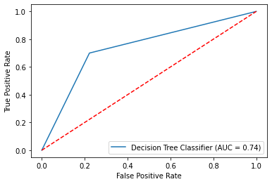

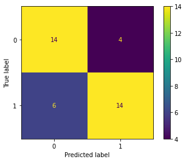

```python
abclf = AdaBoostClassifier(n_estimators=50, learning_rate=1, random_state=12)
abclf = abclf.fit(X_train,y_train)
y_pred = abclf.predict(X_test)
print(classification_report(y_test, y_pred))
fpr, tpr, thresholds = metrics.roc_curve(y_test,y_pred,drop_intermediate=False)
roc_auc = metrics.auc(fpr, tpr)
display = metrics.RocCurveDisplay(fpr=fpr, tpr=tpr, roc_auc=roc_auc, estimator_name='Decision Tree Classifier')
display.plot()  # doctest: +SKIP
plt.plot([0, 1], [0, 1],'r--')
plt.show()
cm = confusion_matrix(y_test, y_pred)
cm_display = ConfusionMatrixDisplay(cm,display_labels=[0,1]).plot()
```

```python
precision,recall,fscore,support=score(y_test,y_pred,average='macro')
print('Precision : {}'.format(precision))
print('Recall    : {}'.format(recall))
print('F-score   : {}'.format(fscore))
#print('Support   : {}'.format(support))

acc.loc[len(acc)] = ['AdaBoostClassifier',precision,recall,fscore,roc_auc]
```

```
Precision : 0.7388888888888889
Recall    : 0.7388888888888889
F-score   : 0.7368421052631577
```

#### 5F. ANN Classifer: Sequential Model Keras

```python
#Import Tensorflow package
import tensorflow as tf
import keras
from keras.models import Sequential
from keras.layers import Dense, Input
from keras.layers import Dropout
from keras.utils.vis_utils import plot_model
tf.random.set_seed(97)
```

```python
Sequential_model=Sequential()
Sequential_model.add(Input(shape=(X_train.shape[1],)))
Sequential_model.add(Dense(7,activation='relu'))
Sequential_model.add(Dense(1))
```

```python
#Compiling model for Classification
Sequential_model.compile(optimizer='adam',loss='binary_crossentropy', metrics=['accuracy'])
```

```python
history = Sequential_model.fit(X_train,y_train, epochs=100,validation_data=(X_test, y_test),validation_split=0.20)
```

```python
Sequential_model.summary()
```

```
Model: "sequential"
_________________________________________________________________
 Layer (type)                Output Shape              Param #
=================================================================
 dense (Dense)               (None, 7)                 63

 dense_1 (Dense)             (None, 1)                 8

=================================================================
Total params: 71
Trainable params: 71
Non-trainable params: 0
_________________________________________________________________
```

```python
test_scores = Sequential_model.evaluate(X_test, y_test)
print("Test loss:", test_scores[0])
print("Test accuracy:", test_scores[1])
```

```
Test loss: 1.64279043674469
Test accuracy: 0.6578947305679321
```

```python
import statistics as st
y_pred = Sequential_model.predict(X_test)
y_pre = (y_pred>(st.median(y_pred)))
```

```
              precision    recall  f1-score   support

           0       0.63      0.67      0.65        18
           1       0.68      0.65      0.67        20

    accuracy                           0.66        38
   macro avg       0.66      0.66      0.66        38
weighted avg       0.66      0.66      0.66        38
```

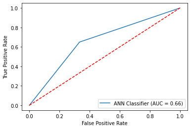

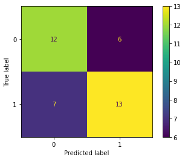

```python
print(classification_report(y_test, y_pre))
fpr, tpr, thresholds = metrics.roc_curve(y_test,y_pre,drop_intermediate=False)
roc_auc = metrics.auc(fpr, tpr)
display = metrics.RocCurveDisplay(fpr=fpr, tpr=tpr, roc_auc=roc_auc, estimator_name='ANN Classifier')
display.plot()  # doctest: +SKIP
plt.plot([0, 1], [0, 1],'r--')
plt.show()
cm = confusion_matrix(y_test, y_pre)
cm_display = ConfusionMatrixDisplay(cm,display_labels=[0,1]).plot()
```

```python
precision,recall,fscore,support=score(y_test,y_pre,average='macro')
print('Precision : {}'.format(precision))
print('Recall    : {}'.format(recall))
print('F-score   : {}'.format(fscore))
#print('Support   : {}'.format(support))

acc.loc[len(acc)] = ['ANN_SequentialModel',precision,recall,fscore,roc_auc]
```

```
Precision : 0.6578947368421053
Recall    : 0.6583333333333333
F-score   : 0.6576576576576576
```

#### 5F. ANN Classifer: Functional Model Keras

```python
from keras import Model
```

```python
inputLayer = Input(shape=(X_train.shape[1],))
hidden1 = Dense(7, activation='softmax')(inputLayer)
hidden2 = Dense(5, activation='relu')(hidden1)
hidden3 = Dense(3, activation='relu')(hidden2)
output = Dense(1, activation='sigmoid')(hidden3)
Functional_model = Model(inputs=inputLayer, outputs=output)
# summarize layers
Functional_model.summary()
```

```
Model: "model_1"
_________________________________________________________________
 Layer (type)                Output Shape              Param #
=================================================================
 input_3 (InputLayer)        [(None, 8)]               0

 dense_6 (Dense)             (None, 7)                 63

 dense_7 (Dense)             (None, 5)                 40

 dense_8 (Dense)             (None, 3)                 18

 dense_9 (Dense)             (None, 1)                 4

=================================================================
Total params: 125
Trainable params: 125
Non-trainable params: 0
_________________________________________________________________
```

```python
#Compiling model for Classification
Functional_model.compile(optimizer='adam',loss='binary_crossentropy', metrics=['accuracy'])
```

```python
history=Functional_model.fit(X_train,y_train, epochs=500,validation_data=(X_test, y_test),validation_split=0.20)
```

```python
test_scores = Functional_model.evaluate(X_test, y_test)
print("Test loss:", test_scores[0])
print("Test accuracy:", test_scores[1])
```

```
Test loss: 0.42986664175987244
Test accuracy: 0.7631579041481018
```

```
              precision    recall  f1-score   support

           0       0.79      0.83      0.81        18
           1       0.84      0.80      0.82        20

    accuracy                           0.82        38
   macro avg       0.82      0.82      0.82        38
weighted avg       0.82      0.82      0.82        38
```

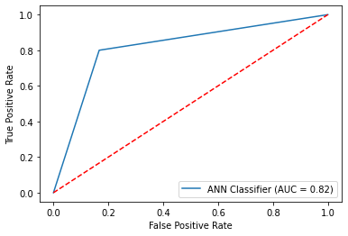

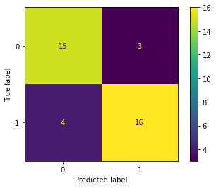

```python
y_pred = Functional_model.predict(X_test)
y_pre = (y_pred>(st.median(y_pred)))
print(classification_report(y_test, y_pre))
fpr, tpr, thresholds = metrics.roc_curve(y_test,y_pre,drop_intermediate=False)
roc_auc = metrics.auc(fpr, tpr)
display = metrics.RocCurveDisplay(fpr=fpr, tpr=tpr, roc_auc=roc_auc, estimator_name='ANN Classifier')
display.plot()  # doctest: +SKIP
plt.plot([0, 1], [0, 1],'r--')
plt.show()
cm = confusion_matrix(y_test, y_pre)
cm_display = ConfusionMatrixDisplay(cm,display_labels=[0,1]).plot()
```

```python
precision,recall,fscore,support=score(y_test,y_pre,average='macro')
print('Precision : {}'.format(precision))
print('Recall    : {}'.format(recall))
print('F-score   : {}'.format(fscore))
#print('Support   : {}'.format(support))

acc.loc[len(acc)] = ['ANN_FunctionalModel',precision,recall,fscore,roc_auc]
```

```
Precision : 0.8157894736842105
Recall    : 0.8166666666666667
F-score   : 0.8156618156618156
```

### 6. Conclusion and Results

```python
acc
```

|  | Model | Precision | Recall | F-Score | roc_auc |
| --- | --- | --- | --- | --- | --- |
| 0 | LogisticRegression | 0.768908 | 0.766667 | 0.762994 | 0.822222 |
| 1 | LinearSVC | 0.768908 | 0.766667 | 0.762994 | 0.766667 |
| 2 | DecisionTreeClassifier | 0.781159 | 0.769444 | 0.761672 | 0.769444 |
| 3 | RandomForestClassifier | 0.822129 | 0.819444 | 0.815662 | 0.819444 |
| 4 | AdaBoostClassifier | 0.738889 | 0.738889 | 0.736842 | 0.738889 |
| 5 | ANN_SequentialModel | 0.657895 | 0.658333 | 0.657658 | 0.658333 |
| 6 | ANN_FunctionalModel | 0.815789 | 0.816667 | 0.815662 | 0.816667 |